# Modelling the progression of hurricanes and other tropical storms using Markov Models

Andrew Pak

### 1 Introduction

#### 1.1 Background Information – Markov Models

One of the central goals of probability theory is the development of techniques to model the evolution of random systems over time. These systems, termed stochastic processes for their random (non-deterministic) behavior, constitute a broad field of research. Consequently, there exists an unlimited set of processes that fit the stochastic framework. Numerous real-world phenomena, ranging from ecological processes to gambling, can be described in terms of an initial condition from which numerous states can extend.

With the wide array of problems that can be represented as stochastic processes, there are multiple modeling methods, each dependant on the core assumptions made and the representation of states the process evolves through. One strong assumption made when analyzing process’s states affirms that the recently observed states will have a more significant effect in determining the next state than would older states. This concept is formalized as the Markov assumption and says that the next state is independent of history, excluding the current state. Markov models are models based off this assumption and are particularly adept at analyzing the behavior of an arbitrary stochastic process with a discrete set of states - ones that are distinct and often non-numerical.

A general case example of a Markov model can be described as follows: a set of discrete states {1,2,….n} and a set of transition probabilities pij describing the probability of going to state j if the current state is state i. These states and transition probabilities can be visualized in the form of a directed graph with nodes representing states and edge weights representing transition probabilities. Transition probabilities can be represented in the form of a transition matrix. These tools help us construct Markov chains of the probabilities of successive changes by iteratively multiplying an initial state vector by the transition matrix to construct possible 2nd, 3rd, up to kth generation states.

Markov models are widely used in a number of probabilistic research topics such as biological sequence analysis [^1], scenario risk analysis for medical decision making [^2], and predicting website navigation patterns [^3]. In this study, we aim to utilize it in creating a stochastic model of the life cycles of tropical storms over the Atlantic Ocean, using the different stages of progression of the storms (i.e. tropical depression, tropical storm, hurricane) as our model states. From this model, we hope to infer properties of certain storm stages, and predict likely paths of progression of storms.

#### 1.2 Related Work

Markov models, with their affinity towards systems with discrete states, have been used in various capacities to model weather patterns, especially episodic phenomena lasting a measurable amount of time. These applications are so common, in fact, that many textbooks use an example Markov model with states representing various generic weather conditions (rainy, cloudy, sunny, etc.) as an introductory, toy example for Markov models.

This simple example has been extended by authors such as Gabriel & Neumann [^4], Rotondo [^5], and Chin [^6] to develop models for predicting precipitation patterns using data from specific areas (Gabriel & Neumann) and aggregated data for larger regions. With the geographic restriction of using data only from one specific area, Gabriel & Neumann are able to derive conclusions regarding the distribution of wet and dry spells and the existence of cyclicity/harmonic components to Tel Aviv’s precipitation patterns. Rotondo and Chin’s aggregate studies develop more generalized Markov models, with less specific inferred conclusions. These papers explain general processes for generating and selecting optimal Markov models of precipitation data.

Modeling tropical storm activity has been a topic of particular interest to hydrologists and meteorologists because the process as clearly defined stages of progression and is also particularly suited to stochastic modeling. Leslie et al [^7] utilized a simple Markov modeling process to generate transitional probabilities for discrete intensity-category states for tropical cyclones off the coast of Australia, selecting time intervals of 24 hours as transitions between states. The resultant Markov models outperformed single-state methods for predicting storm intensity (such as Dvorak) and was one of the first applications of Markov models to tropical storm prediction.

Regnier & Harr [^8] combine principles of risk analysis and decision making with a constructed Markov model for tropical storms to generate decision making models for tropical storm emergency preparations (similar to medical decision methods mentioned above). Instead of using intensity-category states, Regnier & Harr’s model utilizes states based on direction of travel, and uses a smaller (6 hour) time step for transitions. Extensions to this approach are proposed by Lederer [^9], who argues that given direction and geographic location of a storm, a logistic regression model can predict whether it is likely to make landfall – a significant turning point in the lifecycle of a cyclone. Refinements can also be made to Regnier and Harr’s state space by adding additional information such as discrete wind speed categories and speed of forward motion.

#### 1.3 Datasets used

Since 1851, the National Weather Service’s National Hurricane Center has published annual reports of seasonal tropical cyclone activity for both the Atlantic Basin and East Pacific Basin. These reports include synoptic summaries of each cyclone observed, along with the best track data available (updated every 6 hours on the status of the storm through the storm’s life cycle). This track data provides information on the time, geographic location, wind speed, pressure, system status categorizations, and important events in the storm’s life cycle, such as landfall. For more information on the categorizations of system status (the basis for our Markov model states), see appendix.

The data from each of these season reports are aggregated into the HURDAT2 database for each basin, tracking data from 1851 to 2013 seasons in the most recently published iteration of the dataset. [^10]

### 2 – Methodology

We build our markov model using the Atlantic HURDAT2 database available from the National Hurricane Center’s website. The raw dataset contains hurricane information spanning from 1851 to 2013. For quality assurance, we omit any data obtained before the year 2000 - reasons for this are discussed in section 4. For example, data from the 1850’s begins tracking a hurricane only after it has fully formed and does not provide any information detailing the growth of the storm. Although this greatly reduces the size of our data set, we are sure the benefits of a more consistent dataset far outweigh the losses incurred from a truncated dataset. We are, however, forced to assume that by year 2000 the hurricane rating system was well established and that the National Hurricane Center’s detection equipment was sensitive enough to provide accurate and consistent readings. After omitting data prior to year 2000, we are left with a dataset with 7560 different observations, each corresponding to a different Atlantic storm. The data we used was collected exclusively in the North Atlantic region. The North Atlantic region-specific control factors may not be applicable to other regions.

The data was collected in increments of six hours from the start of the storm, and a transition is counted as the change (or lack thereof) in storm state between two consecutive time intervals. We obtained this data from the National Hurricane Center (NHC) website [^11] initially as a comma-separated value (csv) file. We then parsed through the file using the R programming package to store data into or hash tables for ease of access. For more information on the data-parsing process or details on the construction of our transition matrix, see Appendix in the handout. For the remainder of the methods section, we will assume that we have a data structure in place storing the counts of each transition and corresponding time period.

We insert artificial start and stop states (coded as ‘GO’ and “NO”, respectively) to understand how tropical storms progress from initial detection to final dispersion. We go on to assume that all sstorms originate from an original start state and progress until finally reaching the stop state. Our stop state is also an absorption state, or a state from which the hurricane cannot change. Thus, we interpret reaching this stop state as the end of the hurricane. This interpretation does not allow for the possibility of a wind storm dying down and regrowing, but we expect this to be highly unlikely and negligible. Other transition states are defined by a “source” state and a “current” state.

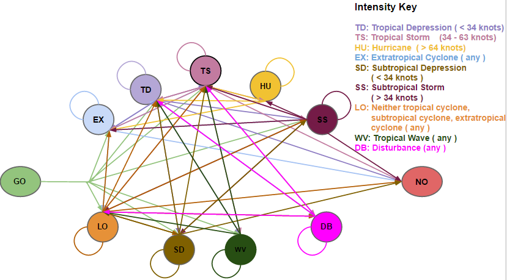

Some may argue the nature of the construction of our transition matrix implies some sort of reliance on previous states, which may violate the “memoryless” assumption of Markov Chains. However, the memoryless assumption is not violated in our case, as we interpret transition A->B as a distinct state, with no reliance on any other transition, say C->D. The logic is the same all other transition states. So in spite of the inherent reliance on source->current, none of our distinct states exhibit dependence on another state, such that the probabilities of such transitions are not influenced by a previous state. As a result, we may still accept our assumption about the memoryless property of our constructed probability matrix.

### 3 Results and Conclusions

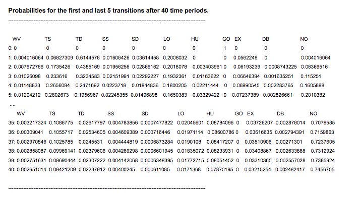

We posed a series of questions regarding the nature of storms in the Atlantic region. Our first question was how long will the average storm last from origin until termination? To answer this question, we applied our transition matrix to our begin vector (containing a 1 only in the ‘GO’ position) and recorded results after every transformation. After analyzing the data, we see that it takes about 40 transformations (40 6-hour time intervals or 10 days) for a storm to have a 75% chance of ending. To achieve a 90% chance of storm termination, the model predicts about 75 transformations, equitable to about 19 days. This interpretation, however, extrapolates beyond the data because we have no storms lasting this length of time.

Our next question was how long will it take for a hurricane to form assuming that the storm has just been conceived. We applied the same procedure as in the first experiment focusing instead on the changes occurring in the hurricane state (HU). We found that it takes about 21 6-hour time intervals (about 5 days) to maximize the probability of a hurricane occurring. The probability of a given storm reaching hurricane levels is only 10.69%, reflecting the real world truth that the conditions necessary for a full sized hurricane occur infrequently. We notice that this peak period happens about halfway through the 75% life cycle of a storm and feel that it is not inaccurate to expect storm intensity to follow a bell curve in which it builds intensity until peaking and lessening intensity until dissipation.

We went on to examine other begin vector states in an attempt to determine how many 6-hour intervals were expected before reaching the stop state given the current state of a storm. The results are surprising because beginning in most states other than the ‘GO’ start state seems to actually delay the storm reaching the ‘NO’ end state. We originally assumed that beginning later in the storm cycle would force termination in the end state sooner, but results contradict this assumption. The only two begin states which accelerate the end state are Extratropical Cyclone (EX) and neither tropical cyclone subtropical cyclone, nor extratropical cyclone (LO). Further research into the nature of these storm categories must be conducted to fully understand these counterintuitive results.

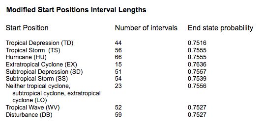

These first three experiments assume we know what state the storm is currently in which allows the Markov Chain to inference future states. Markov Chains, however, are flexible enough to allow some uncertainty. For example, suppose the hurricane analyst is a recent graduate and is inexperienced with storm classifications. The Markov can use probabilistic entries in the begin vector to make inferences, allowing the inexperienced analyst to assign the ‘GO’ state probability .6 and Disturbance (DB) .4 and still predict future states. We experiment with such entries and find the flexibility of the model to be interesting, but results are not as conclusive with probabilistic begin vectors simply because there is a greater amount of uncertainty present in the model.

Finally, we wanted to determine what the most likely path a storm could take was. To accomplish this, we reset our begin vector to start at the ‘GO’ state. Then the Markov Model is iteratively applied to our begin vector to produce future state probabilities. At every iteration, we examine probabilities and assume the state with the highest probability is the next state in the storm’s path. Applying this approach yields the path:

[figure not shown]

### 4 Discussion

#### 4.1 Critiques

When sampling data from the HURDAT2 dataset, data from tropical storm seasons after 2000 were used in the generated Markov model. This was done primarily to remove technological uncertainty from the data, as many of the techniques currently used for collecting storm data were only recently developed (within the last 50 years). As evidenced by the documentation papers for the Atlantic Hurricane Database Re-analysis Project, from which HURDAT2 was produced, aerial reconnaissance only begun after 1944. Since radar/satellite technology likely wasn’t used before then either, all data points before 1950 are unreliable by today’s standards. Some may also argue that tropical storm data should be collected in very limited date range, because of the supposed effect of persistent climate change on the intensity and duration of hurricane seasons. However, extensive research shows that the effects of climate change on hurricane seasons are extremely small. In the end, we arbitrarily selected only data after the year 2000 to ensure that whatever accuracy improvements made until 2013 would have been negligible.

As with any model with variable parameters, our markov model is just one of the infinitely many models that could have been generated to fit this data, each with its own tradeoffs of model bias (higher SSE) and variance (higher SSModel). During our generation of transitional probabilities from the HURDAT2 dataset, we treat each 6-hour time interval in the data as the chosen time-step for a transition from one state to another (Δt = 6). This is the finest level of granularity that we can select; every data point available for each storm is used as a separate transition point. Selecting every available data point allows us to train our model off the greatest amount of data possible. However, this runs the risk of overfitting a model to the data (high bias, high SSModel); this undermines the generalizability of our model to modelling other tropical storm datasets.

Conversely, coarser levels of granularity mean selecting data points in larger time-step intervals; each state would be more than 6 hours apart. This in turn has its own advantages and disadvantages. While the model will by definition use less of the available training data (high variance, high SSE) and some transition states may be skipped entirely, skipped states may show certain states where the progression of cyclones is accelerated / decelerated that may not be reflected in a model developed using fine granularity of data sampling.

Ideally, as in linear regression, model selection can be used to select the optimal level of granularity Δt. Similar papers seem to disagree on a rule of thumb for selecting granularity levels; Leslie selects 24-hour time-steps, while Regnier and Harr use 6-hour time steps. We recommend further studies of the model generated in section 2 while using cross-validation to select between Δt of 6, 12, and 24 hours (varying levels of granularity), which may yield interesting comparative results.

In using maximum likelihood to generate the transition probabilities for our data, we introduce a central assumption into our model: the assumption of a uniform distribution in the set of states. By building our model upon this assumption, we lose a substantial amount of model accuracy - just a quick glance at the states observed in the dataset reveals that some states are clearly more well-represented in the data than others. If we can use prior probabilities of state distributions (generated either from prior domain knowledge or an educated guess), we can utilize a more nuanced maximum likelihood technique to estimate more accurate transition probabilities.

### 5 Appendix

#### 5.1 States used in our model:

##### Intensity Key

TD: Tropical Depression (wind speed < 34 knots)

TS: Tropical Storm (wind speed 34 - 63 knots)

HU: Hurricane (wind speed > 64 knots)

EX: Extratropical Cyclone

SD: Subtropical Depression (wind speed < 34 knots )

SS: Subtropical Storm (wind speed > 34 knots )

LO: Neither tropical cyclone, subtropical cyclone, extratropical cyclone ( any )

WV: Tropical Wave ( any )

DB: Disturbance (any )

### 6 – References

[^1]: Hidden Markov Models in Biological Sequence Analysis http://ieeexplore.ieee.org/search/searchresult.jsp?searchWithin=%22Publication%20Number%22:5288520&searchWithin=%22Volume%22:45&searchWithin=%22Issue%22:3.4&searchWithin=%22Start%20Page%22:449
[^2]: Primer on medical decision analysis: Part 5—Working with Markov processes http://mdm.sagepub.com/content/17/2/152.full.pdf+html
[^3]: The PageRank Citation Ranking: Bringing Order to the Web. http://ilpubs.stanford.edu:8090/422/
[^4]: A Markov chain model for daily rainfall occurrence at Tel Aviv http://dx.doi.org/10.1002/qj.49708837511
[^5]: To Ski or Not to Ski: Estimating Transition Matrices to Predict Tomorrow’??s Snowfall Using Real Data http://www.amstat.org/publications/jse/v18n3/rotondi.pdf
[^6]: Modeling daily precipitation occurrence process with Markov Chain http://dx.doi.org/10.1029/WR013i006p00949
[^7]: Predicting changes in intensity of tropical cyclones using a Markov chain http://www.mi.uni-hamburg.de/fileadmin/files/forschung/theomet/docs/pdf/1992-Leslie-Hess-Holl-Morr-Frae.pdf
[^8]: A Dynamic Decision Model Applied to Hurricane Landfall http://dx.doi.org/10.1175/WAF958.1
[^9]: The Effect of Tropical Cyclone Characteristics on US Landfall Probability http://mosaic.math.tamu.edu/REU/results/REU_2008/lederer.pdf Uses a refined state space to include information about direction/speed of storm travel, along with discrete categories of magnitude
[^10]: HURDAT2 dataset: http://www.nhc.noaa.gov/data/hurdat/hurdat2-1851-2013-052714.txt
[^11]: HURDAT2 dataset: http://www.nhc.noaa.gov/data/hurdat/hurdat2-1851-2013-052714.txt